# R Notebook

# Objective

The objective of this notebook, is to ilustrate **K-means** clustering method using the famous [iris dataset](https://archive.ics.uci.edu/ml/datasets/iris)

# Exploring the data

## Getting the data

```r
library(datasets)
data <- iris
head(data)
```

|  | Sepal.Length | Sepal.Width | Petal.Length | Petal.Width | Species |
| --- | --- | --- | --- | --- | --- |
| 1 | 5.1 | 3.5 | 1.4 | 0.2 | setosa |
| 2 | 4.9 | 3.0 | 1.4 | 0.2 | setosa |
| 3 | 4.7 | 3.2 | 1.3 | 0.2 | setosa |
| 4 | 4.6 | 3.1 | 1.5 | 0.2 | setosa |
| 5 | 5.0 | 3.6 | 1.4 | 0.2 | setosa |
| 6 | 5.4 | 3.9 | 1.7 | 0.4 | setosa |

```r
summary(data)
```

```
##   Sepal.Length    Sepal.Width     Petal.Length    Petal.Width
##  Min.   :4.300   Min.   :2.000   Min.   :1.000   Min.   :0.100
##  1st Qu.:5.100   1st Qu.:2.800   1st Qu.:1.600   1st Qu.:0.300
##  Median :5.800   Median :3.000   Median :4.350   Median :1.300
##  Mean   :5.843   Mean   :3.057   Mean   :3.758   Mean   :1.199
##  3rd Qu.:6.400   3rd Qu.:3.300   3rd Qu.:5.100   3rd Qu.:1.800
##  Max.   :7.900   Max.   :4.400   Max.   :6.900   Max.   :2.500
##        Species
##  setosa    :50
##  versicolor:50
##  virginica :50
##
##
##
```

## Data visualization

So, let’s plot several combinations of groups of 2 features in order to see if there is any visual difference in the discriminatory power of each par of features:

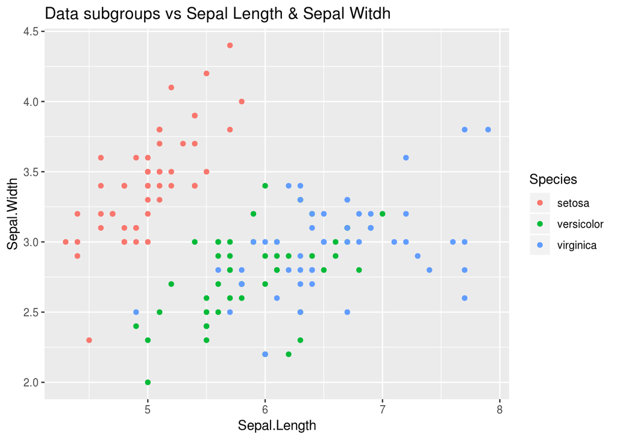

```r
library(ggplot2)
p_setal.l.setal.w <- ggplot(data, aes(Sepal.Length, Sepal.Width, color = Species )) + geom_point() + ggtitle(("Data subgroups vs Sepal Length & Sepal Witdh"))
p_setal.l.setal.w
```

So, we can see that eventhough the setosa species in grouped and very clear, there is a lot of confusion between the species versicolor and virginica.

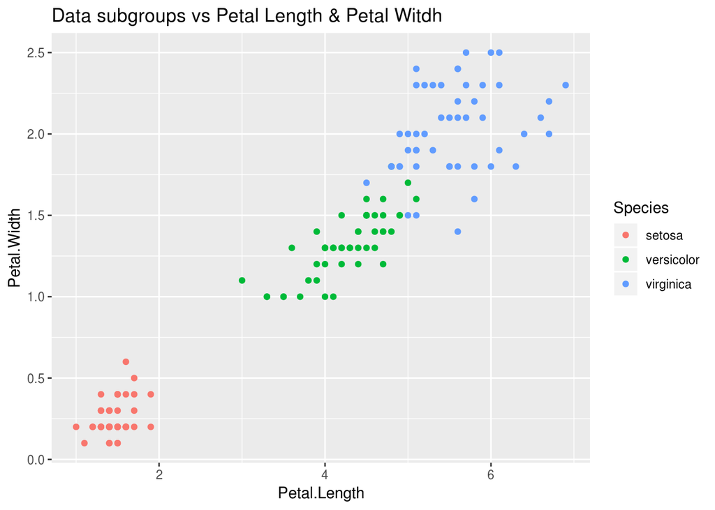

```r
library(ggplot2)
p_petal.l.petal.w <- ggplot(data, aes(Petal.Length, Petal.Width, color = Species )) + geom_point() + ggtitle(("Data subgroups vs Petal Length & Petal Witdh"))
p_petal.l.petal.w
```

We can see that the species are better described by the Petal characteristics than for the Sepal characteristics.

# Clustering Analysis

For further confirmation of the importance of the features selection, let’s run two cluster analysis, one using the Sepal features and another using the Petal features. We will use **K-Means** clustering method.

```r
set.seed(1234)

cluster_sepalfeatures <- kmeans(data[,c("Sepal.Length","Sepal.Width")],3,nstart = 20)
cluster_sepalfeatures
```

```
## K-means clustering with 3 clusters of sizes 50, 47, 53
##
## Cluster means:
##   Sepal.Length Sepal.Width
## 1     5.006000    3.428000
## 2     6.812766    3.074468
## 3     5.773585    2.692453
##
## Clustering vector:
##   [1] 1 1 1 1 1 1 1 1 1 1 1 1 1 1 1 1 1 1 1 1 1 1 1 1 1 1 1 1 1 1 1 1 1 1 1
##  [36] 1 1 1 1 1 1 1 1 1 1 1 1 1 1 1 2 2 2 3 2 3 2 3 2 3 3 3 3 3 3 2 3 3 3 3
##  [71] 3 3 3 3 2 2 2 2 3 3 3 3 3 3 3 3 2 3 3 3 3 3 3 3 3 3 3 3 3 3 2 3 2 2 2
## [106] 2 3 2 2 2 2 2 2 3 3 2 2 2 2 3 2 3 2 3 2 2 3 3 2 2 2 2 2 3 3 2 2 2 3 2
## [141] 2 2 3 2 2 2 3 2 2 3
##
## Within cluster sum of squares by cluster:
## [1] 13.1290 12.6217 11.3000
##  (between_SS / total_SS =  71.6 %)
##
## Available components:
##
## [1] "cluster"      "centers"      "totss"        "withinss"
## [5] "tot.withinss" "betweenss"    "size"         "iter"
## [9] "ifault"
```

```r
cluster_sepalfeatures$tot.withinss
```

```
## [1] 37.0507
```

```r
table(cluster_sepalfeatures$cluster,data$Species)
```

```
##
##     setosa versicolor virginica
##   1     50          0         0
##   2      0         12        35
##   3      0         38        15
```

```r
cluster_petalfeatures <- kmeans(data[,c("Petal.Length","Petal.Width")],3,nstart = 20)
cluster_petalfeatures
```

```
## K-means clustering with 3 clusters of sizes 48, 50, 52
##
## Cluster means:
##   Petal.Length Petal.Width
## 1     5.595833    2.037500
## 2     1.462000    0.246000
## 3     4.269231    1.342308
##
## Clustering vector:
##   [1] 2 2 2 2 2 2 2 2 2 2 2 2 2 2 2 2 2 2 2 2 2 2 2 2 2 2 2 2 2 2 2 2 2 2 2
##  [36] 2 2 2 2 2 2 2 2 2 2 2 2 2 2 2 3 3 3 3 3 3 3 3 3 3 3 3 3 3 3 3 3 3 3 3
##  [71] 3 3 3 3 3 3 3 1 3 3 3 3 3 1 3 3 3 3 3 3 3 3 3 3 3 3 3 3 3 3 1 1 1 1 1
## [106] 1 3 1 1 1 1 1 1 1 1 1 1 1 1 3 1 1 1 1 1 1 3 1 1 1 1 1 1 1 1 1 1 1 3 1
## [141] 1 1 1 1 1 1 1 1 1 1
##
## Within cluster sum of squares by cluster:
## [1] 16.29167  2.02200 13.05769
##  (between_SS / total_SS =  94.3 %)
##
## Available components:
##
## [1] "cluster"      "centers"      "totss"        "withinss"
## [5] "tot.withinss" "betweenss"    "size"         "iter"
## [9] "ifault"
```

```r
cluster_petalfeatures$tot.withinss
```

```
## [1] 31.37136
```

```r
table(cluster_petalfeatures$cluster,data$Species)
```

```
##
##     setosa versicolor virginica
##   1      0          2        46
##   2     50          0         0
##   3      0         48         4
```

From the clustering analysis results, we can see that the analysis performed using the Petal features has a lower within-cluster sum of squares (withinss) than that of using the Sepal features.

Also we can see that in both analysis the setosa species is correctly grouped, but the analysis with the Petal features makes less mistakes classifying the versicolor and the virginica species.

## Visualizing the clustering analysis

Let’s make a plot of both analysis, colring the observations by its cluster label:

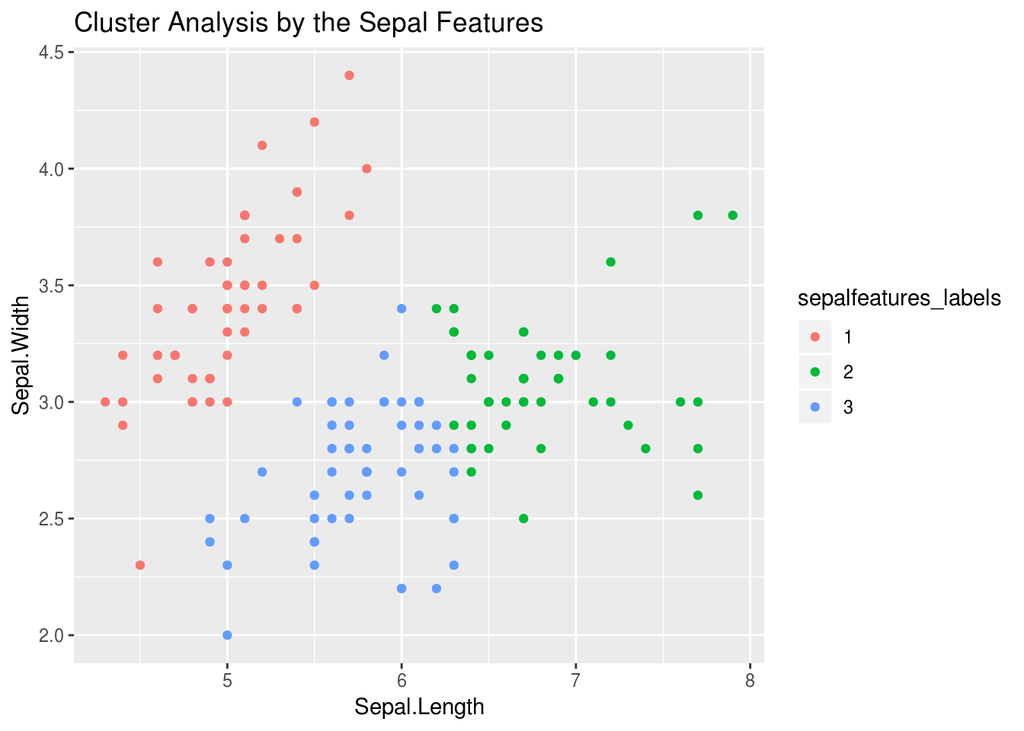

```r
sepalfeatures_labels <- as.factor(cluster_sepalfeatures$cluster)
petalfeatures_labels <- as.factor(cluster_petalfeatures$cluster)

p_sepalfeatures_labels <- ggplot(data, aes(Sepal.Length, Sepal.Width, color = sepalfeatures_labels)) + geom_point() + ggtitle("Cluster Analysis by the Sepal Features")
p_sepalfeatures_labels
```

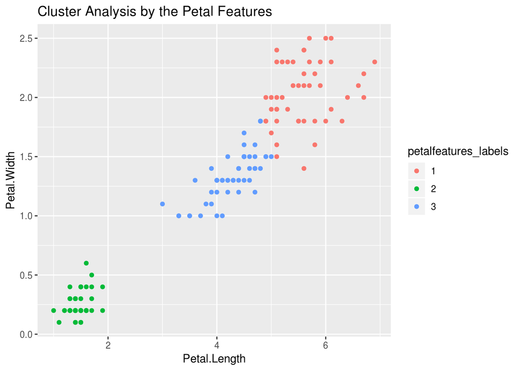

```r
p_petalfeatures_labels <- ggplot(data, aes(Petal.Length, Petal.Width, color = petalfeatures_labels)) + geom_point() + ggtitle("Cluster Analysis by the Petal Features")
p_petalfeatures_labels
```